# Clustering

Vladan Devedzic

## (Installing and) Loading the required R packages

```r
# install.packages("ggplot2")
library(ggplot2)
```

## Dataset

Read and the clean the dataset:  
`source("Prepare The Beatles song dataset for clustering.R")`  
`prepareTheBeatlesDatasetForClustering()`  
`# saveRDS(object = <dataframe or another R object>, file = "<filename>") # save R object for the next session`  
`# <dataframe or another R object> <- readRDS(file = "<filename>") # restore R object in the next session`

```r
the.beatles.songs.num <-
  readRDS("The Beatles songs dataset (numeric), v4.1.RData")
```

## K-Means

### Outliers

Check if there are outliers in the data, using boxplots:  
`boxplot(<dataset>$<column name>, xlab = "<column name>") # basic boxplot for <column name>`  
`boxplot(<dataset>) # basic boxplots for all columns`  
`boxplot(<dataset>)$stats # basic boxplots for all columns, stats`  
`boxplot(<dataset>)$stats[c(1, 5), ] # basic boxplots - whiskers`  
`<output var> <- ggplot(<dataset>, # ggplot2 boxplots`  
`+ aes(x = "",`  
`+ y = <column name>)) + # show boxplot of <column name>`  
`+ geom_boxplot(width = 0.5, fill = "<color>") + # boxplot width and color`  
`+ stat_boxplot(geom ='errorbar', width = 0.15) + # show whiskers, control their width`  
`+ guides(fill = FALSE) + # no legend (it makes no sense here)`  
`+ xlab("") # no x-axis label (it makes no sense here)`

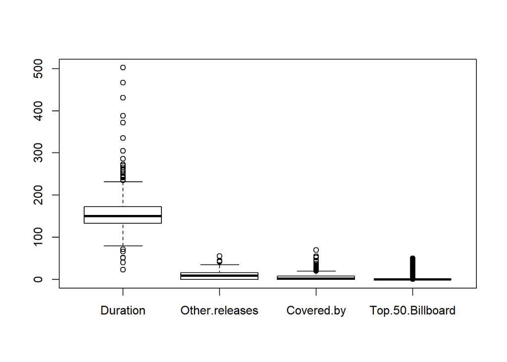

```
##      [,1] [,2] [,3] [,4]
## [1,]   80    0    0    0
## [2,]  133    0    0    0
## [3,]  150    9    2    0
## [4,]  173   16    8    0
## [5,]  232   35   20    0
```

```r
boxplot(the.beatles.songs.num)$stats
```

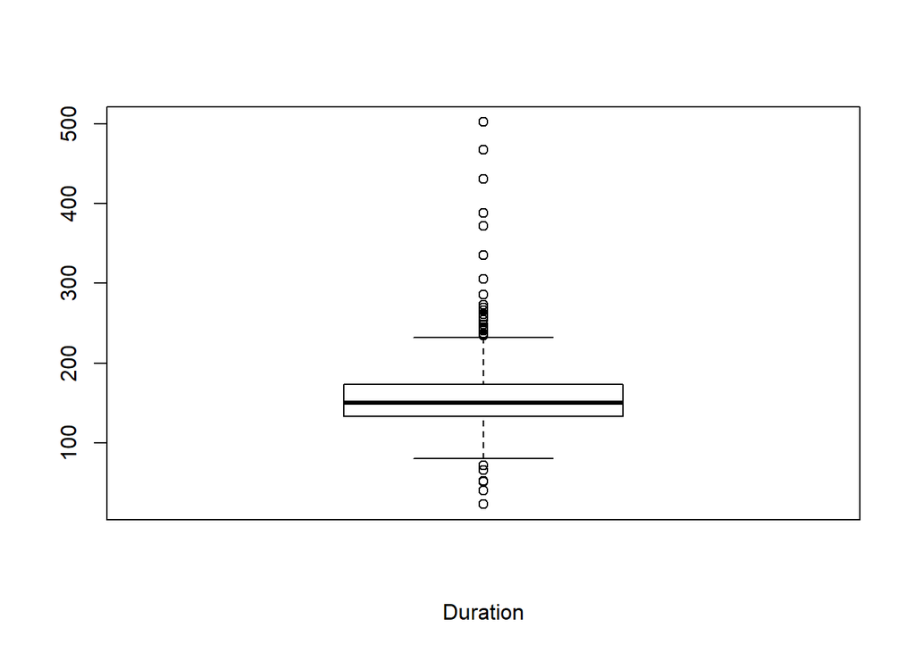

```r
boxplot(the.beatles.songs.num$Duration, xlab = "Duration")
```

Boxplotting all numeric features using the boxplotFeature() utility function:  
`source("Boxplotting.R")`  
`boxplotFeature(<dataset with numeric features>, # dataframe with numeric features`  
`+ "<numeric feature>", # numeric feature to boxplot (its name, passed as a string)`  
`+ "<color>") # boxplot fill color`

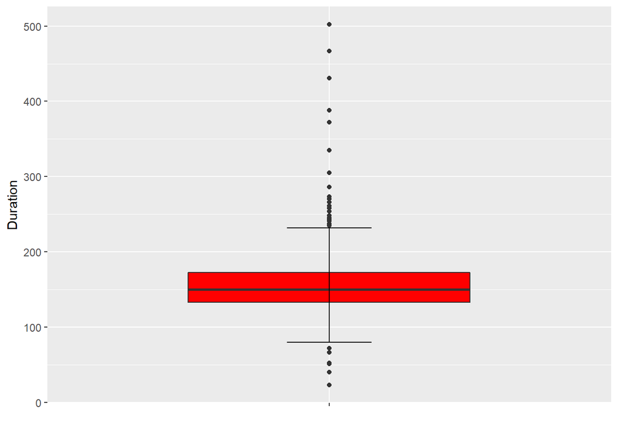

```r
source("Boxplotting.R")
boxplotFeature(the.beatles.songs.num, "Duration", "red")
```

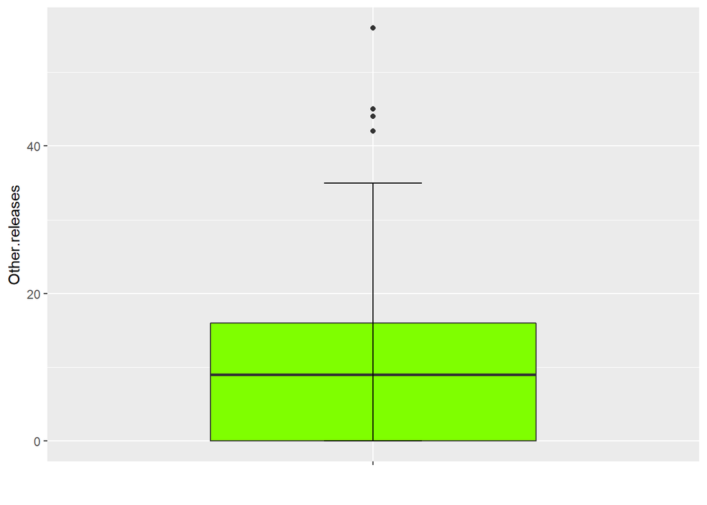

```r
boxplotFeature(the.beatles.songs.num, "Other.releases", "chartreuse")
```

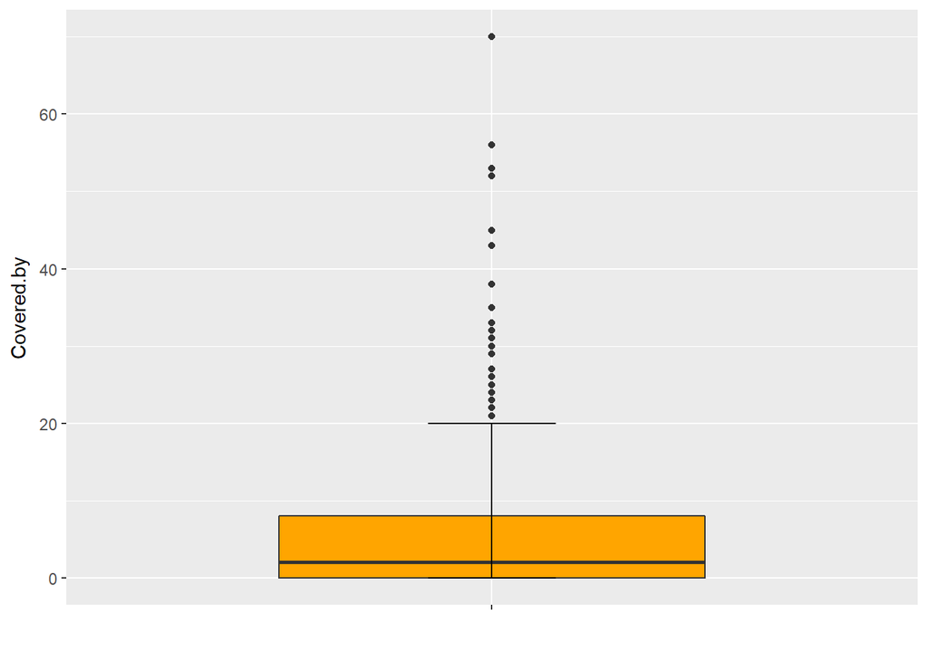

```r
boxplotFeature(the.beatles.songs.num, "Covered.by", "orange")
```

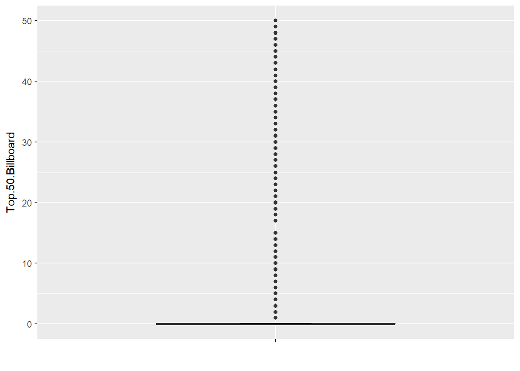

```r
boxplotFeature(the.beatles.songs.num, "Top.50.Billboard", "yellow")
```

Fix the outlier values for each variable with outliers - replace each outlier value with a specific percentile value of the data, typically 90th or 95th:  
`boxplot(<dataset>$<column name>, xlab = "<column name>") # basic boxplot for <column name>`  
`boxplot.stats(<dataset>$<column name>) # examine the boxplot more closely`  
`boxplot.stats(<dataset>$<column name>)$out # examine the outliers more closely`  
`boxplot.stats(<dataset>$<column name>)$stats[c(1, 5)] # get the whiskers`  
`boxplot.stats(<dataset>$<column name>)$stats[1] # get the lower whisker`  
`boxplot.stats(<dataset>$<column name>)$stats[5] # get the upper whisker`  
`sort(boxplot.stats(<dataset>$<column name>)$out) # get and sort the outliers`  
`<quantiles> <- quantile(<dataset>$<column name>, # examine the 90th, 95th, ..., percentile`  
`+ probs = seq(from = 0.9, to = 1, by = 0.025))`  
`<new max value> <- # the value to replace the outliers`  
`+ as.numeric(quantile(<dataset>$<column name>, # pick <percentile> closest to`  
`+ probs = <percentile>)) # the upper whisker`  
`<dataset>$<column name>[<dataset>$<column name> >`  
`+ <new max value>] <- # replace the outliers`  
`+ <new max value>`  
`<quantiles> <- quantile(<dataset>$<column name>, # examine the 0th, 5th, ..., percentile`  
`+ probs = seq(from = 0.0, to = 0.1, by = 0.025))`  
`<new min value> <- # the value to replace the outliers`  
`+ as.numeric(quantile(<dataset>$<column name>, # pick <percentile> closest to`  
`+ probs = <percentile>)) # the lower whisker`  
`<dataset>$<column name>[<dataset>$<column name> < <new min value>] <- # replace the outliers`  
`+ <new min value>`